# Reticulate-Python with R-NLP-Health and Wellness Classifier

```python
modalities.length.describe()
```

```
## count       87.000000
## mean      3842.275862
## std       3103.734864
## min         27.000000
## 25%       1366.500000
## 50%       3191.000000
## 75%       5936.500000
## max      12846.000000
## Name: length, dtype: float64
```

```python
print(list(modalities.Document[modalities.length > 3800].index))
```

```
## [40, 46, 44, 49, 30, 17, 5, 25, 83, 58, 29, 1, 38, 54, 16, 2, 28, 26, 3, 42, 21, 27, 22, 9, 35, 34, 53, 41, 50, 55, 45, 84, 59, 23, 51, 7]
```

```python
print(list(modalities.Topic[modalities.length > 3800]))
```

```
## ['cupping benefits', 'massage gun benefits', 'cupping benefits', 'massage gun benefits', 'mental health services benefits', 'physical therapy benefits', 'massage benefits', 'mental health services benefits', 'ER', 'cold stone benefits', 'mental health services benefits', 'chiropractic benefits', …
```

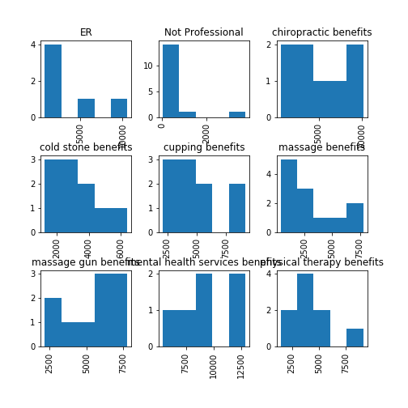

```python
modalities.hist(column='length', by='Topic', bins=5)


plt.show()
```

```python
def split_into_tokens(review):

    return TextBlob(review).words
```

```python
modalities.Document.head().apply(split_into_tokens)
```

```
## 66    [Do, you, prefer, Pastel, Pink, vibes, or, All...
## 40    [What, Is, Cupping, Therapy, And, Should, You,...
## 14    [What, Are, the, Health, Benefits, of, Massage...
## 46    [ll, You, Need, To, Know, About, Massage, Gun,...
## 47    [Benefits, of, Vibration, and, Percussion, The...
## Name: Document, dtype: object
```

```python
TextBlob("hello world, how is it going?").tags  # list of (word, POS) pairs
```

```
## [('hello', 'JJ'), ('world', 'NN'), ('how', 'WRB'), ('is', 'VBZ'), ('it', 'PRP'), ('going', 'VBG')]
```

```python
import nltk
nltk.download('stopwords')
```

```
## True
##
```

```python
from nltk.corpus import stopwords

stop = stopwords.words('english')
stop = stop + [u'a',u'b',u'c',u'd',u'e',u'f',u'g',u'h',u'i',u'j',u'k',u'l',u'm',u'n',u'o',u'p',u'q',u'r',u's',u't',u'v',u'w',u'x',u'y',u'z']
```

```python
def split_into_lemmas(review):
    #review = unicode(review, 'iso-8859-1')
    review = review.lower()
    #review = unicode(review, 'utf8').lower()
    #review = str(review).lower()
    words = TextBlob(review).words
    # for each word, take its "base form" = lemma
    return [word.lemma for word in words if word not in stop]

modalities.Document.head().apply(split_into_lemmas)
```

```
## 66    [prefer, pastel, pink, vibe, black, vibe, lil,...
## 40    [cupping, therapy, try, 're, definitely, going...
## 14    [health, benefit, massage, many, type, massage...
## 46    [need, know, massage, gun, 31, august, 2019, 3...
## 47    [benefit, vibration, percussion, therapy, vibr...
## Name: Document, dtype: object
```

```python
bow_transformer = CountVectorizer(analyzer=split_into_lemmas).fit(modalities['Document'])
print(len(bow_transformer.vocabulary_))
```

```
## 5102
```

```python
modality4 = modalities['Document'][40]
print(modality4)
```

```
##
## What Is Cupping Therapy?And Should You Try It?
##
## You're definitely going to have bruises, JSYK.
## By Annie Daly
## Jun 26, 2018
## Getty Images
##
## Cupping is the wellness trend that just refuses to die.
##
## Seriously?raise your hand if you thought cupping therapy would die down back in 2016 after Michael Phelps permanently exited the pool (it me).
##
## No such luck: Two years later and celebs are still participating in the cupping trend (I see you, Kaley Cuoco and Busy Phillips).
##
## But uh, what exactly is cupping?and what is it used for?
## Alright, WTF is cupping?
##
## Cupping is an ancient Chinese therapy that?s based on the belief that certain health problems can be caused by stagnant blood and a poor energy flow through your body.
##
## To fix or prevent those health issues, cupping practitioners apply cups?typically glass or silicone?to your skin to create a pressure that sucks your skin inward, according to the National Center for Complementary and Integrative Medicine.
## Advertisement - Continue Reading Below
##
## Cupping practitioners usually place cups on a person's back?though face cupping is becoming *a thing* now too?where they'll either leave the cups in place, or slide them around using lotion or oil, per the NCCIM.
##
## Either way, the pressure that the cups create draws blood to the affected area, increasing your blood flow overall, says Chiti Parikh, M.D., integrative medicine practitioner at the Weill Cornell Medicine Integrative Health and Wellbeing Center in New York City.
##
## ?That increased blood flow can relieve muscle tension, improve circulation, and reduce inflammation," says Parikh.
## What's cupping even used for?
##
## Generally, cupping is used to treat chronic pain?back pain and headaches, in particular, says Parikh. ?It?s all about getting rid of musculoskeletal pain, which is often a physical manifestation of chronic stress,? he adds.
##
## More often than not, that chronic stress manifests in how you carry yourself. ?We?re often tensing our muscles when we?re stressed?especially when we?re hunched over our computers and our phones?and that muscle tension can result in physical pain, which is what cupping helps reduce," says Parikh.
## Related Story
## What's Causing Your Chronic Back Pain?
##
## Many people also claim that cupping can help with detoxification, but because "detoxing" really isn't a thing, what they mean is that they are relieving inflammation in the area, Parikh clarifies.
##
## ?When people are suffering from physical pain, that means that inflammation has increased locally in that area. Cupping, then, improves blood circulation in that area by attracting immune cells to that location to increase the repair and recovery process, so that the swelling can go down,? explai…
##
## While there are studies that claim cupping therapy can help reduce chronic pain, like a 2016 study published in the journal Evidence Based Complementary Alternative Medicine, the research is still inconclusive.
```

[output cut: 12 more lines]

```
##
## In short: It's probably not going to do any damage?and hey, it might even help that back pain that's been bugging you for weeks, so go ahead and give it a try.
## Advertisement - Continue Reading Below
##
## Something to keep in mind: Those cups are definitely going to leave big, hickey-like bruises on your skin that can last anywhere from a few days to two weeks?so if that's not something you're interested in, maybe steer clear.
##
## (It should be noted, however, that the color of the mark varies from person to person and doesn't signify how well the cupping worked.)
##
## You'll also want to steer clear of cupping if you?re on blood thinners, have trouble with bleeding or clotting, or you have an open wound, cautions Parikh. The same goes for those with very sensitive or thin skin, she adds. ?You should also avoid cupping on any areas where you have delicate skin,…
##
## If these restrictions do not apply to you and you want to give cupping a whirl, it?s important to find a good practitioner. Parikh says the best cupping practitioners are actually?you guessed it?acupuncturists.
##
## ?To find a good one in your area, I would recommend asking an integrative medicine doctor for a recommendation," says Parikh. "If you don?t know one, your regular doctor will usually be able to refer you to a good one."
##
## Now, go forth and let the cupping begin
```

```python
bow4 = bow_transformer.transform([modality4])
print(bow4)
```

```
##   (0, 3) 2
##   (0, 5) 2
##   (0, 7) 7
##   (0, 75)    2
##   (0, 78)    1
##   (0, 94)    1
##   (0, 184)   2
##   (0, 209)   1
##   (0, 242)   1
##   (0, 245)   3
##   (0, 247)   1
##   (0, 248)   1
##   (0, 251)   2
##   (0, 290)   2
##   (0, 298)   1
##   (0, 319)   1
##   (0, 354)   1
##   (0, 355)   4
##   (0, 361)   1
##   (0, 384)   1
##   (0, 400)   1
##   (0, 417)   1
##   (0, 423)   1
##   (0, 437)   2
##   (0, 451)   7
##   :  :
##   (0, 4721)  1
##   (0, 4735)  2
##   (0, 4740)  1
##   (0, 4744)  1
##   (0, 4824)  3
##   (0, 4827)  1
##   (0, 4828)  2
##   (0, 4847)  1
##   (0, 4914)  2
##   (0, 4935)  4
##   (0, 4949)  2
##   (0, 4955)  1
##   (0, 4958)  2
##   (0, 4962)  1
##   (0, 4963)  1
##   (0, 4985)  1
##   (0, 5013)  2
##   (0, 5014)  1
##   (0, 5016)  1
##   (0, 5028)  2
##   (0, 5029)  1
##   (0, 5038)  1
##   (0, 5047)  1
##   (0, 5058)  1
##   (0, 5070)  1
```

```python
modalities_bow = bow_transformer.transform(modalities['Document'])
print('sparse matrix shape:', modalities_bow.shape)
```

```
## sparse matrix shape: (87, 5102)
```

```python
print('number of non-zeros:', modalities_bow.nnz)
```

```
## number of non-zeros: 17813
```

```python
print('sparsity: %.2f%%' % (100.0 * modalities_bow.nnz / (modalities_bow.shape[0] * modalities_bow.shape[1])))
```

```
## sparsity: 4.01%
```

```python
modalities_bow
```

```
## <87x5102 sparse matrix of type '<class 'numpy.int64'>'
##  with 17813 stored elements in Compressed Sparse Row format>
```

Indexing is different in python compared to R. Python includes zero and when indicating a slice, the last value is ignored, so only up to the value. So it is used to slice, so that the next can start and include that number up to the empty slice which indicates the last value.

```python
# Split/splice into training ~ 80% and testing ~ 20%
modalities_bow_train = modalities_bow[:69]
modalities_bow_test = modalities_bow[69:]
modalities_sentiment_train = modalities['Topic'][:69]
modalities_sentiment_test = modalities['Topic'][69:]

print(modalities_bow_train.shape)
```

```
## (69, 5102)
```

```python
print(modalities_bow_test.shape)
```

```
## (18, 5102)
```

```python
print
```

```
## <built-in function print>
```

```python
modalities_sentiment = MultinomialNB().fit(modalities_bow_train, modalities_sentiment_train)
```

```python
print('predicted:', modalities_sentiment.predict(bow4)[0])
```

```
## predicted: cupping benefits
```

```python
print('expected:', modalities.Topic[40])
```

```
## expected: cupping benefits
```

```python
predictions = modalities_sentiment.predict(modalities_bow_test)
#print(predictions)


prd = pd.DataFrame(predictions)
prd.columns=['predictions']
prd.index=modalities_sentiment_test.index
pred=pd.concat([pd.DataFrame(prd),modalities_sentiment_test],axis=1)
print(pred)
```

```
##                   predictions                      Topic
## 82                         ER                         ER
## 41           cupping benefits           cupping benefits
## 52       massage gun benefits       massage gun benefits
## 65           massage benefits           Not Professional
## 50       massage gun benefits       massage gun benefits
## 55           massage benefits        cold stone benefits
## 45       massage gun benefits       massage gun benefits
## 84                         ER                         ER
## 86                         ER                         ER
## 59        cold stone benefits        cold stone benefits
## 23  physical therapy benefits  physical therapy benefits
## 80       massage gun benefits           Not Professional
## 51       massage gun benefits       massage gun benefits
## 72       massage gun benefits           Not Professional
## 8            massage benefits           massage benefits
## 71           massage benefits           Not Professional
## 6            massage benefits           massage benefits
## 7            massage benefits           massage benefits
```

```python
print('accuracy', accuracy_score(modalities_sentiment_test, predictions))
```

```
## accuracy 0.7222222222222222
```

```python
print('confusion matrix\n', confusion_matrix(modalities_sentiment_test, predictions))
```

```
## confusion matrix
##  [[3 0 0 0 0 0 0]
##  [0 0 0 0 2 2 0]
##  [0 0 1 0 1 0 0]
##  [0 0 0 1 0 0 0]
##  [0 0 0 0 3 0 0]
##  [0 0 0 0 0 4 0]
##  [0 0 0 0 0 0 1]]
```

```python
print('(row=expected, col=predicted)')
```

```
## (row=expected, col=predicted)
```

```python
print(classification_report(modalities_sentiment_test, predictions))
```

```
##                            precision    recall  f1-score   support
##
##                        ER       1.00      1.00      1.00         3
##          Not Professional       0.00      0.00      0.00         4
##       cold stone benefits       1.00      0.50      0.67         2
##          cupping benefits       1.00      1.00      1.00         1
##          massage benefits       0.50      1.00      0.67         3
##      massage gun benefits       0.67      1.00      0.80         4
## physical therapy benefits       1.00      1.00      1.00         1
##
##                  accuracy                           0.72        18
##                 macro avg       0.74      0.79      0.73        18
##              weighted avg       0.62      0.72      0.64        18
##
##
```

From the above, precision accounts for type 1 errors (how many real negatives classified as positives-False Positives: TP/(TP+FP)) and type 2 errors (how many real posiives classified as negatives-False Negatives: TP/(TP+FN)) are part of recall.

```python
modalitiesu = modalities.Topic.unique()
mus = np.sort(modalitiesu)
mus
```

```
## array(['ER', 'Not Professional', 'chiropractic benefits',
##        'cold stone benefits', 'cupping benefits', 'massage benefits',
##        'massage gun benefits', 'mental health services benefits',
##        'physical therapy benefits'], dtype=object)
```

The ‘Not Professional’ class is not getting sorted alphabetically with the others nor is the ER class. This may be because of the uppercase priority in sorting that effects the order of probability readings.

```python
def predict_modality(new_review):
    new_sample = bow_transformer.transform([new_review])
    pr = np.around(modalities_sentiment.predict_proba(new_sample),2)
    print(new_review,'\n\n', pr)
    print('\n\nThe respective order:\n 0-ER\n 1-Non Professional\n 2-chiropractic therapy\n 3-cold stone therapy\n 4-cupping therapy\n 5-massage therapy\n 6-massage gun therapy\n 7-mental health therapy\n 8-physical therapy\n\n')

    if (pr[0][0] == max(pr[0])):
        print('The max probability is Emergency Room services for this recommendation with ', pr[0][0]*100,'%')
    elif (pr[0][1] == max(pr[0])):
        print('The max probability is Non-Professional services for this recommendation with ', pr[0][1]*100,'%')

    elif (pr[0][2] == max(pr[0])):
        print('The max probability is chiropractic therapy for this recommendation with ', pr[0][2]*100,'%')

    elif (pr[0][3] == max(pr[0])):
        print('The max probability is cold stone massage for this recommendation with ', pr[0][3]*100,'%')

    elif (pr[0][4] == max(pr[0])):
        print('The max probability is cupping therapy for this recommendation with ', pr[0][4]*100,'%')

    elif (pr[0][5] == max(pr[0])):
        print('The max probability is massage therapy for this recommendation with ', pr[0][5]*100,'%')

    elif (pr[0][6] == max(pr[0])):
        print('The max probability is massage gun therapy for this recommendation with ', pr[0][6]*100,'%')

    elif (pr[0][7] == max(pr[0])):
        print('The max probability is mental health therapy for this recommendation with ', pr[0][7]*100,'%')

    else:
        print('The max probability is physical therapy for this recommendation with ', pr[0][8]*100,'%')

    print('-----------------------------------------\n\n')
```

```python
predict_modality('Headaches, body sweats, depressed.')
```

```
## Headaches, body sweats, depressed.
##
##  [[0.   0.03 0.33 0.07 0.02 0.51 0.01 0.01 0.01]]
##
##
## The respective order:
##  0-ER
##  1-Non Professional
##  2-chiropractic therapy
##  3-cold stone therapy
##  4-cupping therapy
##  5-massage therapy
##  6-massage gun therapy
##  7-mental health therapy
##  8-physical therapy
##
##
## The max probability is massage therapy for this recommendation with  51.0 %
## -----------------------------------------
```

```python
predict_modality('sleepless, energy depraved, cold, tension')
```

```
## sleepless, energy depraved, cold, tension
##
##  [[0.   0.   0.01 0.94 0.04 0.01 0.   0.   0.  ]]
##
##
## The respective order:
##  0-ER
##  1-Non Professional
##  2-chiropractic therapy
##  3-cold stone therapy
##  4-cupping therapy
##  5-massage therapy
##  6-massage gun therapy
##  7-mental health therapy
##  8-physical therapy
##
##
## The max probability is cold stone massage for this recommendation with  94.0 %
## -----------------------------------------
```

```python
predict_modality('body aches from working out')
```

```
## body aches from working out
##
##  [[0.   0.12 0.05 0.16 0.11 0.22 0.19 0.07 0.08]]
##
##
## The respective order:
##  0-ER
##  1-Non Professional
##  2-chiropractic therapy
##  3-cold stone therapy
##  4-cupping therapy
##  5-massage therapy
##  6-massage gun therapy
##  7-mental health therapy
##  8-physical therapy
##
##
## The max probability is massage therapy for this recommendation with  22.0 %
## -----------------------------------------
```

```python
predict_modality('can\'t move my arm. stuck at home. worried about my neck.')
```

```
## can't move my arm. stuck at home. worried about my neck.
##
##  [[0.03 0.   0.2  0.02 0.04 0.37 0.13 0.   0.2 ]]
##
##
## The respective order:
##  0-ER
##  1-Non Professional
##  2-chiropractic therapy
##  3-cold stone therapy
##  4-cupping therapy
##  5-massage therapy
##  6-massage gun therapy
##  7-mental health therapy
##  8-physical therapy
##
##
## The max probability is massage therapy for this recommendation with  37.0 %
## -----------------------------------------
```

```python
predict_modality('breathing ragged, tired, headaches, dizzy, nausious ')
```

```
## breathing ragged, tired, headaches, dizzy, nausious
##
##  [[0.12 0.03 0.36 0.06 0.02 0.37 0.01 0.01 0.01]]
##
##
## The respective order:
##  0-ER
##  1-Non Professional
##  2-chiropractic therapy
##  3-cold stone therapy
##  4-cupping therapy
##  5-massage therapy
##  6-massage gun therapy
##  7-mental health therapy
##  8-physical therapy
##
##
## The max probability is massage therapy for this recommendation with  37.0 %
## -----------------------------------------
```

```python
predict_modality("relief from this pain. can't sleep. feet hurt. chills.")
```

```
## relief from this pain. can't sleep. feet hurt. chills.
##
##  [[0.   0.   0.3  0.   0.04 0.56 0.01 0.   0.09]]
##
##
## The respective order:
##  0-ER
##  1-Non Professional
##  2-chiropractic therapy
##  3-cold stone therapy
##  4-cupping therapy
##  5-massage therapy
##  6-massage gun therapy
##  7-mental health therapy
##  8-physical therapy
##
##
## The max probability is massage therapy for this recommendation with  56.00000000000001 %
## -----------------------------------------
```

```python
predict_modality('love this place better than others')
```

```
## love this place better than others
##
##  [[0.01 0.1  0.09 0.05 0.3  0.02 0.01 0.39 0.03]]
##
##
## The respective order:
##  0-ER
##  1-Non Professional
##  2-chiropractic therapy
##  3-cold stone therapy
##  4-cupping therapy
##  5-massage therapy
##  6-massage gun therapy
##  7-mental health therapy
##  8-physical therapy
##
##
## The max probability is mental health therapy for this recommendation with  39.0 %
## -----------------------------------------
```

```python
from sklearn.feature_extraction.text import TfidfVectorizer

bow_transformerTFIDF = TfidfVectorizer(analyzer=split_into_lemmas).fit(modalities['Document'])
print(len(bow_transformerTFIDF.vocabulary_))
```

```
## 5102
```

```python
modality4 = modalities['Document'][40]
print(modality4)
```

```
##
## What Is Cupping Therapy?And Should You Try It?
##
## You're definitely going to have bruises, JSYK.
## By Annie Daly
## Jun 26, 2018
## Getty Images
##
## Cupping is the wellness trend that just refuses to die.
##
## Seriously?raise your hand if you thought cupping therapy would die down back in 2016 after Michael Phelps permanently exited the pool (it me).
##
## No such luck: Two years later and celebs are still participating in the cupping trend (I see you, Kaley Cuoco and Busy Phillips).
##
## But uh, what exactly is cupping?and what is it used for?
## Alright, WTF is cupping?
##
## Cupping is an ancient Chinese therapy that?s based on the belief that certain health problems can be caused by stagnant blood and a poor energy flow through your body.
##
## To fix or prevent those health issues, cupping practitioners apply cups?typically glass or silicone?to your skin to create a pressure that sucks your skin inward, according to the National Center for Complementary and Integrative Medicine.
## Advertisement - Continue Reading Below
##
## Cupping practitioners usually place cups on a person's back?though face cupping is becoming *a thing* now too?where they'll either leave the cups in place, or slide them around using lotion or oil, per the NCCIM.
##
## Either way, the pressure that the cups create draws blood to the affected area, increasing your blood flow overall, says Chiti Parikh, M.D., integrative medicine practitioner at the Weill Cornell Medicine Integrative Health and Wellbeing Center in New York City.
##
## ?That increased blood flow can relieve muscle tension, improve circulation, and reduce inflammation," says Parikh.
## What's cupping even used for?
##
## Generally, cupping is used to treat chronic pain?back pain and headaches, in particular, says Parikh. ?It?s all about getting rid of musculoskeletal pain, which is often a physical manifestation of chronic stress,? he adds.
##
## More often than not, that chronic stress manifests in how you carry yourself. ?We?re often tensing our muscles when we?re stressed?especially when we?re hunched over our computers and our phones?and that muscle tension can result in physical pain, which is what cupping helps reduce," says Parikh.
## Related Story
## What's Causing Your Chronic Back Pain?
##
## Many people also claim that cupping can help with detoxification, but because "detoxing" really isn't a thing, what they mean is that they are relieving inflammation in the area, Parikh clarifies.
##
## ?When people are suffering from physical pain, that means that inflammation has increased locally in that area. Cupping, then, improves blood circulation in that area by attracting immune cells to that location to increase the repair and recovery process, so that the swelling can go down,? explai…
##
## While there are studies that claim cupping therapy can help reduce chronic pain, like a 2016 study published in the journal Evidence Based Complementary Alternative Medicine, the research is still inconclusive.
```

[output cut: 12 more lines]

```
##
## In short: It's probably not going to do any damage?and hey, it might even help that back pain that's been bugging you for weeks, so go ahead and give it a try.
## Advertisement - Continue Reading Below
##
## Something to keep in mind: Those cups are definitely going to leave big, hickey-like bruises on your skin that can last anywhere from a few days to two weeks?so if that's not something you're interested in, maybe steer clear.
##
## (It should be noted, however, that the color of the mark varies from person to person and doesn't signify how well the cupping worked.)
##
## You'll also want to steer clear of cupping if you?re on blood thinners, have trouble with bleeding or clotting, or you have an open wound, cautions Parikh. The same goes for those with very sensitive or thin skin, she adds. ?You should also avoid cupping on any areas where you have delicate skin,…
##
## If these restrictions do not apply to you and you want to give cupping a whirl, it?s important to find a good practitioner. Parikh says the best cupping practitioners are actually?you guessed it?acupuncturists.
##
## ?To find a good one in your area, I would recommend asking an integrative medicine doctor for a recommendation," says Parikh. "If you don?t know one, your regular doctor will usually be able to refer you to a good one."
##
## Now, go forth and let the cupping begin
```

```python
bow4 = bow_transformerTFIDF.transform([modality4])
print(bow4)
```

```
##   (0, 5070)  0.0343016955623061
##   (0, 5058)  0.02351775744233836
##   (0, 5047)  0.017109259657448753
##   (0, 5038)  0.0343016955623061
##   (0, 5029)  0.026424862252912722
##   (0, 5028)  0.03421851931489751
##   (0, 5016)  0.018160377636647154
##   (0, 5014)  0.02933196706348709
##   (0, 5013)  0.02333325109144081
##   (0, 4985)  0.0343016955623061
##   (0, 4963)  0.019392510065849074
##   (0, 4962)  0.03139459075173173
##   (0, 4958)  0.029771020055084946
##   (0, 4955)  0.0343016955623061
##   (0, 4949)  0.03709605788703871
##   (0, 4935)  0.05954204011016989
##   (0, 4914)  0.03421851931489751
##   (0, 4847)  0.03139459075173173
##   (0, 4828)  0.03878502013169815
##   (0, 4827)  0.013780280073305366
##   (0, 4824)  0.041340840219916096
##   (0, 4744)  0.0343016955623061
##   (0, 4740)  0.021455133754093716
##   (0, 4735)  0.03709605788703871
##   (0, 4721)  0.02436223856466808
##   :  :
##   (0, 451)   0.08852091625908796
##   (0, 437)   0.045524686673871696
##   (0, 423)   0.02436223856466808
##   (0, 417)   0.01679054929193511
##   (0, 400)   0.0343016955623061
##   (0, 384)   0.026424862252912722
##   (0, 361)   0.019392510065849074
##   (0, 355)   0.04113417730901512
##   (0, 354)   0.0343016955623061
##   (0, 319)   0.026424862252912722
##   (0, 298)   0.021455133754093716
##   (0, 290)   0.052849724505825445
##   (0, 251)   0.05866393412697418
##   (0, 248)   0.02933196706348709
##   (0, 247)   0.03139459075173173
##   (0, 245)   0.06623696446880327
##   (0, 242)   0.022762343336935848
##   (0, 209)   0.017442798989282242
##   (0, 184)   0.03791568698219916
##   (0, 94)    0.02933196706348709
##   (0, 78)    0.022762343336935848
##   (0, 75)    0.05063926459735123
##   (0, 7) 0.11976481760214126
##   (0, 5) 0.04291026750818743
##   (0, 3) 0.052849724505825445
```

```python
modalities_bow = bow_transformerTFIDF.transform(modalities['Document'])
print('sparse matrix shape:', modalities_bow.shape)
```

```
## sparse matrix shape: (87, 5102)
```

```python
print('number of non-zeros:', modalities_bow.nnz)
```

```
## number of non-zeros: 17813
```

```python
print('sparsity: %.2f%%' % (100.0 * modalities_bow.nnz / (modalities_bow.shape[0] * modalities_bow.shape[1])))
```

```
## sparsity: 4.01%
```

```python
modalities_bow
```

```
## <87x5102 sparse matrix of type '<class 'numpy.float64'>'
##  with 17813 stored elements in Compressed Sparse Row format>
```

```python
# Split/splice into training ~ 80% and testing ~ 20%
modalities_bow_train = modalities_bow[:69]
modalities_bow_test = modalities_bow[69:]
modalities_sentiment_train = modalities['Topic'][:69]
modalities_sentiment_test = modalities['Topic'][69:]

print(modalities_bow_train.shape)
```

```
## (69, 5102)
```

```python
print(modalities_bow_test.shape)
```

```
## (18, 5102)
```

```python
print
```

```
## <built-in function print>
```

```python
modalities_sentiment = MultinomialNB().fit(modalities_bow_train, modalities_sentiment_train)
```

```python
print('predicted:', modalities_sentiment.predict(bow4)[0])
```

```
## predicted: cupping benefits
```

```python
print('expected:', modalities.Topic[40])
```

```
## expected: cupping benefits
```

```python
predictions = modalities_sentiment.predict(modalities_bow_test)
# print(predictions)

prd = pd.DataFrame(predictions)
prd.columns=['predictions']

prd.index=modalities_sentiment_test.index
pred=pd.concat([pd.DataFrame(prd),modalities_sentiment_test],axis=1)
print(pred)
```

```
##                   predictions                      Topic
## 82           Not Professional                         ER
## 41           cupping benefits           cupping benefits
## 52           massage benefits       massage gun benefits
## 65           Not Professional           Not Professional
## 50       massage gun benefits       massage gun benefits
## 55           massage benefits        cold stone benefits
## 45           massage benefits       massage gun benefits
## 84           Not Professional                         ER
## 86           Not Professional                         ER
## 59        cold stone benefits        cold stone benefits
## 23  physical therapy benefits  physical therapy benefits
## 80           Not Professional           Not Professional
## 51       massage gun benefits       massage gun benefits
## 72           Not Professional           Not Professional
## 8            massage benefits           massage benefits
## 71           Not Professional           Not Professional
## 6            massage benefits           massage benefits
## 7            massage benefits           massage benefits
```

```python
print('accuracy', accuracy_score(modalities_sentiment_test, predictions))
```

```
## accuracy 0.6666666666666666
```

```python
print('confusion matrix\n', confusion_matrix(modalities_sentiment_test, predictions))
```

```
## confusion matrix
##  [[0 3 0 0 0 0 0]
##  [0 4 0 0 0 0 0]
##  [0 0 1 0 1 0 0]
##  [0 0 0 1 0 0 0]
##  [0 0 0 0 3 0 0]
##  [0 0 0 0 2 2 0]
##  [0 0 0 0 0 0 1]]
```

```python
print('(row=expected, col=predicted)')
```

```
## (row=expected, col=predicted)
```

```python
print(classification_report(modalities_sentiment_test, predictions))
```

```
##                            precision    recall  f1-score   support
##
##                        ER       0.00      0.00      0.00         3
##          Not Professional       0.57      1.00      0.73         4
##       cold stone benefits       1.00      0.50      0.67         2
##          cupping benefits       1.00      1.00      1.00         1
##          massage benefits       0.50      1.00      0.67         3
##      massage gun benefits       1.00      0.50      0.67         4
## physical therapy benefits       1.00      1.00      1.00         1
##
##                  accuracy                           0.67        18
##                 macro avg       0.72      0.71      0.68        18
##              weighted avg       0.65      0.67      0.61        18
##
##
```

From the above, precision accounts for type 1 errors (how many real negatives classified as positives-False Positives: TP/(TP+FP)) and type 2 errors (how many real posiives classified as negatives-False Negatives: TP/(TP+FN)) are part of recall.

```python
modalitiesu = modalities.Topic.unique()
mus = np.sort(modalitiesu)
mus
```

```
## array(['ER', 'Not Professional', 'chiropractic benefits',
##        'cold stone benefits', 'cupping benefits', 'massage benefits',
##        'massage gun benefits', 'mental health services benefits',
##        'physical therapy benefits'], dtype=object)
```

```python
def predict_modality(new_review):
    new_sample = bow_transformerTFIDF.transform([new_review])
    pr = np.around(modalities_sentiment.predict_proba(new_sample),2)
    print(new_review,'\n\n', pr)
    print('\n\nThe respective order:\n 0-ER\n 1-Non Professional\n 2-chiropractic therapy\n 3-cold stone therapy\n 4-cupping therapy\n 5-massage therapy\n 6-massage gun therapy\n 7-mental health therapy\n 8-physical therapy\n\n')

    if (pr[0][0] == max(pr[0])):
        print('The max probability is Emergency Room services for this recommendation with ', pr[0][0]*100,'%')
    elif (pr[0][1] == max(pr[0])):
        print('The max probability is Non-Professional services for this recommendation with ', pr[0][1]*100,'%')

    elif (pr[0][2] == max(pr[0])):
        print('The max probability is chiropractic therapy for this recommendation with ', pr[0][2]*100,'%')

    elif (pr[0][3] == max(pr[0])):
        print('The max probability is cold stone massage for this recommendation with ', pr[0][3]*100,'%')

    elif (pr[0][4] == max(pr[0])):
        print('The max probability is cupping therapy for this recommendation with ', pr[0][4]*100,'%')

    elif (pr[0][5] == max(pr[0])):
        print('The max probability is massage therapy for this recommendation with ', pr[0][5]*100,'%')

    elif (pr[0][6] == max(pr[0])):
        print('The max probability is massage gun therapy for this recommendation with ', pr[0][6]*100,'%')

    elif (pr[0][7] == max(pr[0])):
        print('The max probability is mental health therapy for this recommendation with ', pr[0][7]*100,'%')

    else:
        print('The max probability is physical therapy for this recommendation with ', pr[0][8]*100,'%')

    print('-----------------------------------------\n\n')
```

```python
predict_modality('Headaches, body sweats, depressed.')
```

```
## Headaches, body sweats, depressed.
##
##  [[0.04 0.16 0.13 0.12 0.12 0.16 0.08 0.08 0.11]]
##
##
## The respective order:
##  0-ER
##  1-Non Professional
##  2-chiropractic therapy
##  3-cold stone therapy
##  4-cupping therapy
##  5-massage therapy
##  6-massage gun therapy
##  7-mental health therapy
##  8-physical therapy
##
##
## The max probability is Non-Professional services for this recommendation with  16.0 %
## -----------------------------------------
```

```python
predict_modality('sleepless, energy depraved, cold, tension')
```

```
## sleepless, energy depraved, cold, tension
##
##  [[0.04 0.14 0.1  0.23 0.12 0.12 0.07 0.07 0.09]]
##
##
## The respective order:
##  0-ER
##  1-Non Professional
##  2-chiropractic therapy
##  3-cold stone therapy
##  4-cupping therapy
##  5-massage therapy
##  6-massage gun therapy
##  7-mental health therapy
##  8-physical therapy
##
##
## The max probability is cold stone massage for this recommendation with  23.0 %
## -----------------------------------------
```

```python
predict_modality('body aches from working out')
```

```
## body aches from working out
##
##  [[0.04 0.17 0.11 0.12 0.13 0.14 0.09 0.08 0.12]]
##
##
## The respective order:
##  0-ER
##  1-Non Professional
##  2-chiropractic therapy
##  3-cold stone therapy
##  4-cupping therapy
##  5-massage therapy
##  6-massage gun therapy
##  7-mental health therapy
##  8-physical therapy
##
##
## The max probability is Non-Professional services for this recommendation with  17.0 %
## -----------------------------------------
```

```python
predict_modality('can\'t move my arm. stuck at home. worried about my neck.')
```

```
## can't move my arm. stuck at home. worried about my neck.
##
##  [[0.04 0.16 0.12 0.11 0.13 0.14 0.09 0.08 0.13]]
##
##
## The respective order:
##  0-ER
##  1-Non Professional
##  2-chiropractic therapy
##  3-cold stone therapy
##  4-cupping therapy
##  5-massage therapy
##  6-massage gun therapy
##  7-mental health therapy
##  8-physical therapy
##
##
## The max probability is Non-Professional services for this recommendation with  16.0 %
## -----------------------------------------
```

```python
predict_modality('breathing ragged, tired, headaches, dizzy, nausious ')
```

```
## breathing ragged, tired, headaches, dizzy, nausious
##
##  [[0.05 0.16 0.12 0.12 0.13 0.15 0.08 0.08 0.11]]
##
##
## The respective order:
##  0-ER
##  1-Non Professional
##  2-chiropractic therapy
##  3-cold stone therapy
##  4-cupping therapy
##  5-massage therapy
##  6-massage gun therapy
##  7-mental health therapy
##  8-physical therapy
##
##
## The max probability is Non-Professional services for this recommendation with  16.0 %
## -----------------------------------------
```

```python
predict_modality("relief from this pain. can't sleep. feet hurt. chills.")
```

```
## relief from this pain. can't sleep. feet hurt. chills.
##
##  [[0.04 0.14 0.14 0.1  0.12 0.15 0.08 0.07 0.15]]
##
##
## The respective order:
##  0-ER
##  1-Non Professional
##  2-chiropractic therapy
##  3-cold stone therapy
##  4-cupping therapy
##  5-massage therapy
##  6-massage gun therapy
##  7-mental health therapy
##  8-physical therapy
##
##
## The max probability is massage therapy for this recommendation with  15.0 %
## -----------------------------------------
```

```python
predict_modality('love this place better than others')
```

```
## love this place better than others
##
##  [[0.04 0.18 0.11 0.11 0.14 0.12 0.08 0.09 0.11]]
##
##
## The respective order:
##  0-ER
##  1-Non Professional
##  2-chiropractic therapy
##  3-cold stone therapy
##  4-cupping therapy
##  5-massage therapy
##  6-massage gun therapy
##  7-mental health therapy
##  8-physical therapy
##
##
## The max probability is Non-Professional services for this recommendation with  18.0 %
## -----------------------------------------
```

The TF-IDF vectorized dtm performed worse in recommending an accurate class for the testing set and the short user inputs. Lets try out the N-grams and see if it is better.

**N-gram Vectorization**

```python
modalities = pd.read_csv('benefitsContraindications3.csv', encoding = 'unicode_escape')
```

```python
import regex
def preprocessor(text):
    text = regex.sub('<[^>]*>', '', text)
    emoticons = regex.findall('(?::|;|=)(?:-)?(?:\)|\(|D|P)', text)
    text = regex.sub('[\W]+', ' ', text.lower()) +\
        ' '.join(emoticons).replace('-', '')
    return text
```

Reorder the observations so that they are mixed and not grouped together as they are in the original file.

```python
import numpy as np

modalities = modalities.reindex(np.random.permutation(modalities.index))

print(modalities.head())
```

```
##                                              Document  ...                                risksAdverseEffects
## 37  \r\nCupping Therapy\r\nIn this Article\r\n\r\n...  ...                                                NaN
## 66  Do you prefer Pastel Pink vibes or All Black v...  ...                                                NaN
## 31  \r\n21 Benefits of Chiropractic Adjustments\r\...  ...                                                NaN
## 13  \r\nThai Massage\r\n\r\nDuring a Thai massage,...  ...                                                NaN
## 2    The Safety of Chiropractic Adjustments\r\nBy ...  ...  Risks and side effects associated with chiropr...
##
## [5 rows x 6 columns]
```

```python
print(modalities.tail())
```

```
##                                              Document  ... risksAdverseEffects
## 80  So I'm meeting with my CPA yesterday.  Great g...  ...                 NaN
## 30   Mental Health Counselor Training, Skills, and...  ...                 NaN
## 72        I adore men who massage me all over my body  ...                 NaN
## 41  \r\n    Benefit\r\n    Possible Side Effects\r...  ...                 NaN
## 77  Whens the last time you gave your man a back ...  ...                 NaN
##
## [5 rows x 6 columns]
```

```python
def split_into_tokens(review):

    return TextBlob(review).words
```

```python
modalities.Document.head().apply(split_into_tokens)
```

```
## 37    [Cupping, Therapy, In, this, Article, Types, W...
## 66    [Do, you, prefer, Pastel, Pink, vibes, or, All...
## 31    [21, Benefits, of, Chiropractic, Adjustments, ...
## 13    [Thai, Massage, During, a, Thai, massage, the,...
## 2     [The, Safety, of, Chiropractic, Adjustments, B...
## Name: Document, dtype: object
```

```python
TextBlob("hello world, how is it going?").tags  # list of (word, POS) pairs
```

```
## [('hello', 'JJ'), ('world', 'NN'), ('how', 'WRB'), ('is', 'VBZ'), ('it', 'PRP'), ('going', 'VBG')]
```

```python
import nltk
nltk.download('stopwords')
```

```
## True
##
```

```python
from nltk.corpus import stopwords

stop = stopwords.words('english')
stop = stop + [u'a',u'b',u'c',u'd',u'e',u'f',u'g',u'h',u'i',u'j',u'k',u'l',u'm',u'n',u'o',u'p',u'q',u'r',u's',u't',u'v',u'w',u'x',u'y',u'z']
```

```python
def split_into_lemmas(review):
    #review = unicode(review, 'iso-8859-1')
    review = review.lower()
    #review = unicode(review, 'utf8').lower()
    #review = str(review).lower()
    words = TextBlob(review).words
    # for each word, take its "base form" = lemma
    return [word.lemma for word in words if word not in stop]

modalities.Document.head().apply(split_into_lemmas)
```

```
## 37    [cupping, therapy, article, type, research, sh...
## 66    [prefer, pastel, pink, vibe, black, vibe, lil,...
## 31    [21, benefit, chiropractic, adjustment, woman,...
## 13    [thai, massage, thai, massage, therapist, us, ...
## 2     [safety, chiropractic, adjustment, lana, barhu...
## Name: Document, dtype: object
```

```python
bow_transformerNgrams = CountVectorizer(analyzer=split_into_lemmas,ngram_range=(2,2)).fit(modalities['Document'])

print(len(bow_transformerNgrams.vocabulary_))
```

```
## 5102
```

```python
modality4 = modalities['Document'][40]
print(modality4)
```

```
##
## What Is Cupping Therapy?And Should You Try It?
##
## You're definitely going to have bruises, JSYK.
## By Annie Daly
## Jun 26, 2018
## Getty Images
##
## Cupping is the wellness trend that just refuses to die.
##
## Seriously?raise your hand if you thought cupping therapy would die down back in 2016 after Michael Phelps permanently exited the pool (it me).
##
## No such luck: Two years later and celebs are still participating in the cupping trend (I see you, Kaley Cuoco and Busy Phillips).
##
## But uh, what exactly is cupping?and what is it used for?
## Alright, WTF is cupping?
##
## Cupping is an ancient Chinese therapy that?s based on the belief that certain health problems can be caused by stagnant blood and a poor energy flow through your body.
##
## To fix or prevent those health issues, cupping practitioners apply cups?typically glass or silicone?to your skin to create a pressure that sucks your skin inward, according to the National Center for Complementary and Integrative Medicine.
## Advertisement - Continue Reading Below
##
## Cupping practitioners usually place cups on a person's back?though face cupping is becoming *a thing* now too?where they'll either leave the cups in place, or slide them around using lotion or oil, per the NCCIM.
##
## Either way, the pressure that the cups create draws blood to the affected area, increasing your blood flow overall, says Chiti Parikh, M.D., integrative medicine practitioner at the Weill Cornell Medicine Integrative Health and Wellbeing Center in New York City.
##
## ?That increased blood flow can relieve muscle tension, improve circulation, and reduce inflammation," says Parikh.
## What's cupping even used for?
##
## Generally, cupping is used to treat chronic pain?back pain and headaches, in particular, says Parikh. ?It?s all about getting rid of musculoskeletal pain, which is often a physical manifestation of chronic stress,? he adds.
##
## More often than not, that chronic stress manifests in how you carry yourself. ?We?re often tensing our muscles when we?re stressed?especially when we?re hunched over our computers and our phones?and that muscle tension can result in physical pain, which is what cupping helps reduce," says Parikh.
## Related Story
## What's Causing Your Chronic Back Pain?
##
## Many people also claim that cupping can help with detoxification, but because "detoxing" really isn't a thing, what they mean is that they are relieving inflammation in the area, Parikh clarifies.
##
## ?When people are suffering from physical pain, that means that inflammation has increased locally in that area. Cupping, then, improves blood circulation in that area by attracting immune cells to that location to increase the repair and recovery process, so that the swelling can go down,? explai…
##
## While there are studies that claim cupping therapy can help reduce chronic pain, like a 2016 study published in the journal Evidence Based Complementary Alternative Medicine, the research is still inconclusive.
```

[output cut: 12 more lines]

```
##
## In short: It's probably not going to do any damage?and hey, it might even help that back pain that's been bugging you for weeks, so go ahead and give it a try.
## Advertisement - Continue Reading Below
##
## Something to keep in mind: Those cups are definitely going to leave big, hickey-like bruises on your skin that can last anywhere from a few days to two weeks?so if that's not something you're interested in, maybe steer clear.
##
## (It should be noted, however, that the color of the mark varies from person to person and doesn't signify how well the cupping worked.)
##
## You'll also want to steer clear of cupping if you?re on blood thinners, have trouble with bleeding or clotting, or you have an open wound, cautions Parikh. The same goes for those with very sensitive or thin skin, she adds. ?You should also avoid cupping on any areas where you have delicate skin,…
##
## If these restrictions do not apply to you and you want to give cupping a whirl, it?s important to find a good practitioner. Parikh says the best cupping practitioners are actually?you guessed it?acupuncturists.
##
## ?To find a good one in your area, I would recommend asking an integrative medicine doctor for a recommendation," says Parikh. "If you don?t know one, your regular doctor will usually be able to refer you to a good one."
##
## Now, go forth and let the cupping begin
```

```python
bow4 = bow_transformerNgrams.transform([modality4])
print(bow4)
```

```
##   (0, 3) 2
##   (0, 5) 2
##   (0, 7) 7
##   (0, 75)    2
##   (0, 78)    1
##   (0, 94)    1
##   (0, 184)   2
##   (0, 209)   1
##   (0, 242)   1
##   (0, 245)   3
##   (0, 247)   1
##   (0, 248)   1
##   (0, 251)   2
##   (0, 290)   2
##   (0, 298)   1
##   (0, 319)   1
##   (0, 354)   1
##   (0, 355)   4
##   (0, 361)   1
##   (0, 384)   1
##   (0, 400)   1
##   (0, 417)   1
##   (0, 423)   1
##   (0, 437)   2
##   (0, 451)   7
##   :  :
##   (0, 4721)  1
##   (0, 4735)  2
##   (0, 4740)  1
##   (0, 4744)  1
##   (0, 4824)  3
##   (0, 4827)  1
##   (0, 4828)  2
##   (0, 4847)  1
##   (0, 4914)  2
##   (0, 4935)  4
##   (0, 4949)  2
##   (0, 4955)  1
##   (0, 4958)  2
##   (0, 4962)  1
##   (0, 4963)  1
##   (0, 4985)  1
##   (0, 5013)  2
##   (0, 5014)  1
##   (0, 5016)  1
##   (0, 5028)  2
##   (0, 5029)  1
##   (0, 5038)  1
##   (0, 5047)  1
##   (0, 5058)  1
##   (0, 5070)  1
```

```python
modalities_bow = bow_transformerNgrams.transform(modalities['Document'])
print('sparse matrix shape:', modalities_bow.shape)
```

```
## sparse matrix shape: (87, 5102)
```

```python
print('number of non-zeros:', modalities_bow.nnz)
```

```
## number of non-zeros: 17813
```

```python
print('sparsity: %.2f%%' % (100.0 * modalities_bow.nnz / (modalities_bow.shape[0] * modalities_bow.shape[1])))
```

```
## sparsity: 4.01%
```

```python
modalities_bow
```

```
## <87x5102 sparse matrix of type '<class 'numpy.int64'>'
##  with 17813 stored elements in Compressed Sparse Row format>
```

```python
# Split/splice into training ~ 80% and testing ~ 20%
modalities_bow_train = modalities_bow[:69]
modalities_bow_test = modalities_bow[69:]
modalities_sentiment_train = modalities['Topic'][:69]
modalities_sentiment_test = modalities['Topic'][69:]

print(modalities_bow_train.shape)
```

```
## (69, 5102)
```

```python
print(modalities_bow_test.shape)
```

```
## (18, 5102)
```

```python
print
```

```
## <built-in function print>
```

```python
modalities_sentiment = MultinomialNB().fit(modalities_bow_train, modalities_sentiment_train)
```

```python
print('predicted:', modalities_sentiment.predict(bow4)[0])
```

```
## predicted: cupping benefits
```

```python
print('expected:', modalities.Topic[40])
```

```
## expected: cupping benefits
```

```python
predictions = modalities_sentiment.predict(modalities_bow_test)

prd = pd.DataFrame(predictions)
prd.columns=['predictions']
prd.index=modalities_sentiment_test.index
pred=pd.concat([pd.DataFrame(prd),modalities_sentiment_test],axis=1)
print(pred)
```

```
##                         predictions                            Topic
## 19        physical therapy benefits        physical therapy benefits
## 22        physical therapy benefits        physical therapy benefits
## 58              cold stone benefits              cold stone benefits
## 53             massage gun benefits             massage gun benefits
## 79                 massage benefits                 Not Professional
## 8                  massage benefits                 massage benefits
## 60              cold stone benefits              cold stone benefits
## 84                               ER                               ER
## 7              massage gun benefits                 massage benefits
## 34            chiropractic benefits            chiropractic benefits
## 43                 cupping benefits                 cupping benefits
## 49             massage gun benefits             massage gun benefits
## 14                 massage benefits                 massage benefits
## 80                 massage benefits                 Not Professional
## 30  mental health services benefits  mental health services benefits
## 72                 massage benefits                 Not Professional
## 41                 cupping benefits                 cupping benefits
## 77                 massage benefits                 Not Professional
```

```python
print('accuracy', accuracy_score(modalities_sentiment_test, predictions))
```

```
## accuracy 0.7222222222222222
```

```python
print('confusion matrix\n', confusion_matrix(modalities_sentiment_test, predictions))
```

```
## confusion matrix
##  [[1 0 0 0 0 0 0 0 0]
##  [0 0 0 0 0 4 0 0 0]
##  [0 0 1 0 0 0 0 0 0]
##  [0 0 0 2 0 0 0 0 0]
##  [0 0 0 0 2 0 0 0 0]
##  [0 0 0 0 0 2 1 0 0]
##  [0 0 0 0 0 0 2 0 0]
##  [0 0 0 0 0 0 0 1 0]
##  [0 0 0 0 0 0 0 0 2]]
```

```python
print('(row=expected, col=predicted)')
```

```
## (row=expected, col=predicted)
```

```python
print(classification_report(modalities_sentiment_test, predictions))
```

```
##                                  precision    recall  f1-score   support
##
##                              ER       1.00      1.00      1.00         1
##                Not Professional       0.00      0.00      0.00         4
##           chiropractic benefits       1.00      1.00      1.00         1
##             cold stone benefits       1.00      1.00      1.00         2
##                cupping benefits       1.00      1.00      1.00         2
##                massage benefits       0.33      0.67      0.44         3
##            massage gun benefits       0.67      1.00      0.80         2
## mental health services benefits       1.00      1.00      1.00         1
##       physical therapy benefits       1.00      1.00      1.00         2
##
##                        accuracy                           0.72        18
##                       macro avg       0.78      0.85      0.80        18
##                    weighted avg       0.63      0.72      0.66        18
##
##
```

From the above, precision accounts for type 1 errors (how many real negatives classified as positives-False Positives: TP/(TP+FP)) and type 2 errors (how many real posiives classified as negatives-False Negatives: TP/(TP+FN)) are part of recall.

```python
modalitiesu = modalities.Topic.unique()
mus = np.sort(modalitiesu)
mus
```

```
## array(['ER', 'Not Professional', 'chiropractic benefits',
##        'cold stone benefits', 'cupping benefits', 'massage benefits',
##        'massage gun benefits', 'mental health services benefits',
##        'physical therapy benefits'], dtype=object)
```

```python
def predict_modality(new_review):
    new_sample = bow_transformerNgrams.transform([new_review])
    pr = np.around(modalities_sentiment.predict_proba(new_sample),2)
    print(new_review,'\n\n', pr)
    print('\n\nThe respective order:\n 0-ER\n 1-Non Professional\n 2-chiropractic therapy\n 3-cold stone therapy\n 4-cupping therapy\n 5-massage therapy\n 6-massage gun therapy\n 7-mental health therapy\n 8-physical therapy\n\n')

    if (pr[0][0] == max(pr[0])):
        print('The max probability is Emergency Room services for this recommendation with ', pr[0][0]*100,'%')
    elif (pr[0][1] == max(pr[0])):
        print('The max probability is Non-Professional services for this recommendation with ', pr[0][1]*100,'%')

    elif (pr[0][2] == max(pr[0])):
        print('The max probability is chiropractic therapy for this recommendation with ', pr[0][2]*100,'%')

    elif (pr[0][3] == max(pr[0])):
        print('The max probability is cold stone massage for this recommendation with ', pr[0][3]*100,'%')

    elif (pr[0][4] == max(pr[0])):
        print('The max probability is cupping therapy for this recommendation with ', pr[0][4]*100,'%')

    elif (pr[0][5] == max(pr[0])):
        print('The max probability is massage therapy for this recommendation with ', pr[0][5]*100,'%')

    elif (pr[0][6] == max(pr[0])):
        print('The max probability is massage gun therapy for this recommendation with ', pr[0][6]*100,'%')

    elif (pr[0][7] == max(pr[0])):
        print('The max probability is mental health therapy for this recommendation with ', pr[0][7]*100,'%')

    else:
        print('The max probability is physical therapy for this recommendation with ', pr[0][8]*100,'%')

    print('-----------------------------------------\n\n')
```

```python
predict_modality('Headaches, body sweats, depressed.')
```

```
## Headaches, body sweats, depressed.
##
##  [[0.01 0.01 0.28 0.22 0.01 0.41 0.04 0.01 0.01]]
##
##
## The respective order:
##  0-ER
##  1-Non Professional
##  2-chiropractic therapy
##  3-cold stone therapy
##  4-cupping therapy
##  5-massage therapy
##  6-massage gun therapy
##  7-mental health therapy
##  8-physical therapy
##
##
## The max probability is massage therapy for this recommendation with  41.0 %
## -----------------------------------------
```

```python
predict_modality('sleepless, energy depraved, cold, tension')
```

```
## sleepless, energy depraved, cold, tension
##
##  [[0.   0.   0.02 0.89 0.06 0.01 0.02 0.   0.  ]]
##
##
## The respective order:
##  0-ER
##  1-Non Professional
##  2-chiropractic therapy
##  3-cold stone therapy
##  4-cupping therapy
##  5-massage therapy
##  6-massage gun therapy
##  7-mental health therapy
##  8-physical therapy
##
##
## The max probability is cold stone massage for this recommendation with  89.0 %
## -----------------------------------------
```

```python
predict_modality('body aches from working out')
```

```
## body aches from working out
##
##  [[0.   0.02 0.04 0.08 0.06 0.15 0.6  0.02 0.04]]
##
##
## The respective order:
##  0-ER
##  1-Non Professional
##  2-chiropractic therapy
##  3-cold stone therapy
##  4-cupping therapy
##  5-massage therapy
##  6-massage gun therapy
##  7-mental health therapy
##  8-physical therapy
##
##
## The max probability is massage gun therapy for this recommendation with  60.0 %
## -----------------------------------------
```

```python
predict_modality('can\'t move my arm. stuck at home. worried about my neck.')
```

```
## can't move my arm. stuck at home. worried about my neck.
##
##  [[0.15 0.01 0.11 0.03 0.03 0.56 0.07 0.01 0.05]]
##
##
## The respective order:
##  0-ER
##  1-Non Professional
##  2-chiropractic therapy
##  3-cold stone therapy
##  4-cupping therapy
##  5-massage therapy
##  6-massage gun therapy
##  7-mental health therapy
##  8-physical therapy
##
##
## The max probability is massage therapy for this recommendation with  56.00000000000001 %
## -----------------------------------------
```

```python
predict_modality('breathing ragged, tired, headaches, dizzy, nausious ')
```

```
## breathing ragged, tired, headaches, dizzy, nausious
##
##  [[0.24 0.03 0.29 0.27 0.01 0.13 0.01 0.01 0.01]]
##
##
## The respective order:
##  0-ER
##  1-Non Professional
##  2-chiropractic therapy
##  3-cold stone therapy
##  4-cupping therapy
##  5-massage therapy
##  6-massage gun therapy
##  7-mental health therapy
##  8-physical therapy
##
##
## The max probability is chiropractic therapy for this recommendation with  28.999999999999996 %
## -----------------------------------------
```

```python
predict_modality("relief from this pain. can't sleep. feet hurt. chills.")
```

```
## relief from this pain. can't sleep. feet hurt. chills.
##
##  [[0.   0.   0.19 0.01 0.02 0.64 0.12 0.   0.02]]
##
##
## The respective order:
##  0-ER
##  1-Non Professional
##  2-chiropractic therapy
##  3-cold stone therapy
##  4-cupping therapy
##  5-massage therapy
##  6-massage gun therapy
##  7-mental health therapy
##  8-physical therapy
##
##
## The max probability is massage therapy for this recommendation with  64.0 %
## -----------------------------------------
```

```python
predict_modality('love this place better than others')
```

```
## love this place better than others
##
##  [[0.01 0.02 0.09 0.19 0.18 0.03 0.1  0.37 0.02]]
##
##
## The respective order:
##  0-ER
##  1-Non Professional
##  2-chiropractic therapy
##  3-cold stone therapy
##  4-cupping therapy
##  5-massage therapy
##  6-massage gun therapy
##  7-mental health therapy
##  8-physical therapy
##
##
## The max probability is mental health therapy for this recommendation with  37.0 %
## -----------------------------------------
```

For now lets look at the word clouds now, when the data is scrubbed of risks/negative side effects/contraindications, and with the ER services class. ***

```r
library(tidytext)
library(tm)
library(dplyr)
library(ggplot2)
library(tidyr)
library(wordcloud)
```

Lets read in the csv file if you don’t have it stored as Reviews15_results.

```r
modalities <- read.csv('benefitsContraindications3.csv',
                              sep=',', header=TRUE, na.strings=c('',' ','NA'))
```

```r
colnames(modalities)
```

```
## [1] "Document"            "Source"              "Topic"
## [4] "InternetSearch"      "Contraindications"   "risksAdverseEffects"
```

```r
modalities1 <- modalities[,c(1,3)]
head(modalities1)
```

```
##                                                                                                                                                                                                                                                                                                          …
## 1                                                                                                                                                                                                                                                                                                        …
## 2                                                                                                                                                                                                                                                                                                        …
## 3                                                                                                                                                                                                                                                                                                        …
## 4 Advanced Chiropractic Relief: 8 Key Benefits of Chiropractor Care\n\nAre you one of the 50 million Americans who suffer from chronic pain? If so you?re probably intimately familiar with the feeling of pure desperation that can arise from an inability to find relief.\n\nIn addition to physical i…
## 5                                                                                                                                                                                                                                                                                                        …
## 6                                                                                                                                                                                                                                                                                                        …
##                   Topic
## 1 chiropractic benefits
## 2 chiropractic benefits
## 3 chiropractic benefits
## 4 chiropractic benefits
## 5      massage benefits
## 6      massage benefits
```

We are to make our data table into a dplyr tibble.

```r
text_df <- tibble(line=1:87, text=modalities1$Document,
                  Recommend=modalities1$Topic)
head(text_df)
```

```
## # A tibble: 6 x 3
##    line text                                                   Recommend
##   <int> <fct>                                                  <fct>
## 1     1 "Chiropractic adjustments and treatments serve the ne~ chiropractic ben~
## 2     2 "\nUnitedHealthcare Combats Opioid Crisis with Non-Op~ chiropractic ben~
## 3     3 " The Safety of Chiropractic Adjustments\nBy Lana Bar~ chiropractic ben~
## 4     4 "Advanced Chiropractic Relief: 8 Key Benefits of Chir~ chiropractic ben~
## 5     5 "Heading to the spa can be a pampering treat, but it ~ massage benefits
## 6     6 "Massage: Get in touch with its many benefits\n\nMass~ massage benefits
```

```r
text_df$text <- as.character(paste(text_df$text))

fills <- as.data.frame(c('of','the','a','an','in','by','it','as','or','go','goes','am','and','to'))
colnames(fills) <- 'fillers'

text_df0 <- text_df %>% unnest_tokens(bigram,text,token='ngrams',n=2) %>%
  separate(bigram, c('word1','word2'), sep=' ')

text_df01 <- anti_join(text_df0,fills, by=c("word1"="fillers"))
text_df02 <- anti_join(text_df01,fills, by=c("word2"="fillers"))

text_df02$bigram <- paste(text_df02$word1,text_df02$word2,sep=' ')
text_df03 <- text_df02[,-c(2:4)]

text_df1 <- text_df %>% unnest_tokens(bigram,text, token='ngrams',n=2)
text_df2 <- merge(text_df1,text_df03, by.x='bigram', by.y='bigram', all.y=FALSE)

text_df3 <- text_df2[,-4]
colnames(text_df3)[2] <- 'line'
head(text_df3,30)
```

```
##                                                                                     bigram
## 1   _______________________________________________________________________________ damkee
## 2    _______________________________________________________________________________ mebak
## 3  _______________________________________________________________________________ sylphim
## 4                                                                                      0 6
## 5                                                                               0 comments
## 6                                                                                  01 03pm
## 7                                                                                  02 2013
## 8                                                                                  02 2019
## 9                                                                                  02 2020
## 10                                                                           02 futuristic
## 11                                                                                   03 02
## 12                                                                                 03 2020
## 13                                                                                03pm edt
## 14                                                                                   04 30
```

[output cut: 47 more lines]

```r
text_df4 <- text_df3 %>% group_by(bigram) %>% count(bigram, sort=TRUE) %>% ungroup
head(text_df4,30)
```

```
## # A tibble: 30 x 2
##    bigram               n
##    <chr>            <int>
##  1 mental health    25281
##  2 physical therapy 11236
##  3 massage gun       9409
##  4 massage therapy   7744
##  5 if you            7225
##  6 massage guns      6241
##  7 can be            5625
##  8 can help          5041
##  9 you can           3600
## 10 stone massage     3249
## # ... with 20 more rows
```

The above shows all documents bigram occurences of word pairs.

We want the recommended modality or health care option for each category counts of bigrams.

```r
er <- subset(text_df3, text_df3$Recommend=='ER')
nonPro <- subset(text_df3, text_df3$Recommend=='Not Professional')
chiropractor <- subset(text_df3, text_df3$Recommend=='chiropractic benefits')
massage <- subset(text_df3, text_df3$Recommend=='massage benefits')
physicalTherapy <- subset(text_df3, text_df3$Recommend=='physical therapy benefits')
mental <- subset(text_df3, text_df3$Recommend=='mental health services benefits')
cupping <- subset(text_df3, text_df3$Recommend=='cupping benefits')
massageGun <- subset(text_df3, text_df3$Recommend=='massage gun benefits')
coldStone <- subset(text_df3, text_df3$Recommend=='cold stone benefits')
```

Group each category into bigram counts.

```r
er2 <- er %>% group_by(bigram) %>% count(bigram, sort=TRUE)
er3 <- spread(er2,bigram,n)
freqER <- colSums(er3)

nonPro2 <- nonPro %>% group_by(bigram) %>% count(bigram, sort=TRUE)
nonPro3 <- spread(nonPro2,bigram,n)
freqNonPro <- colSums(nonPro3)

chiropractor2 <- chiropractor %>% group_by(bigram) %>% count(bigram, sort=TRUE)
chiropractor3 <- spread(chiropractor2,bigram,n)
freqChiropractor <- colSums(chiropractor3)

massage2 <- massage %>% group_by(bigram) %>% count(bigram, sort=TRUE)
massage3 <- spread(massage2,bigram,n)
freqMassage <- colSums(massage3)

physical2 <- physicalTherapy %>% group_by(bigram) %>% count(bigram, sort=TRUE)
physical3 <- spread(physical2,bigram,n)
freqPhysical <- colSums(physical3)

mental2 <- mental %>% group_by(bigram) %>% count(bigram, sort=TRUE)
mental3 <- spread(mental2,bigram,n)
freqMental <- colSums(mental3)

cupping2 <- cupping %>% group_by(bigram) %>% count(bigram, sort=TRUE)
cupping3 <- spread(cupping2,bigram,n)
freqCupping <- colSums(cupping3)

massageGun2 <- massageGun %>% group_by(bigram) %>% count(bigram, sort=TRUE)
massageGun3 <- spread(massageGun2,bigram,n)
freqMassageGun <- colSums(massageGun3)

coldStone2 <- coldStone %>% group_by(bigram) %>% count(bigram, sort=TRUE)
coldStone3 <- spread(coldStone2,bigram,n)
freqColdStone <- colSums(coldStone3)
```

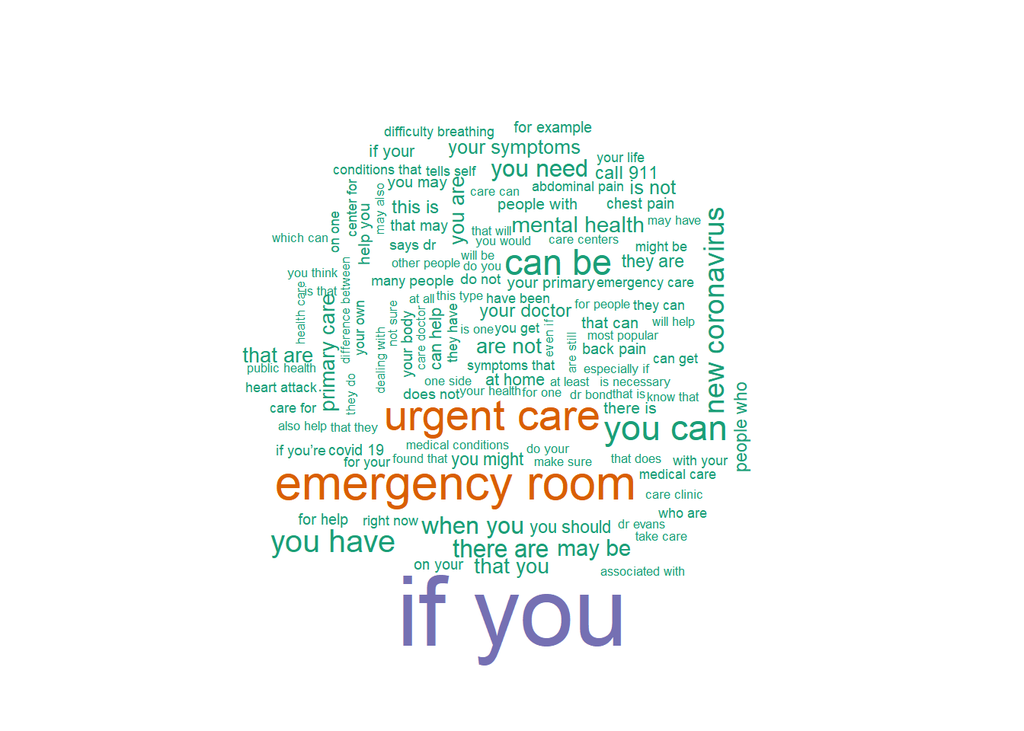

```r
wordcloud(names(freqER), freqER,
          min.freq=10,colors=brewer.pal(3,'Dark2'))
```

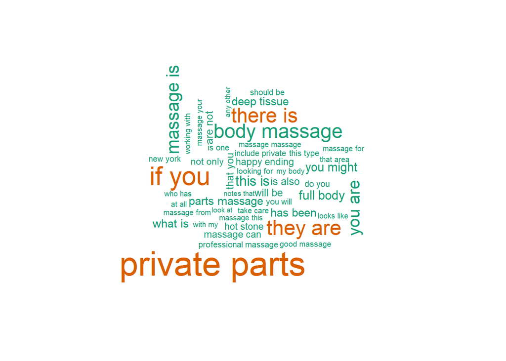

```r
wordcloud(names(freqNonPro), freqNonPro,
          min.freq=5,colors=brewer.pal(3,'Dark2'))
```

The above shows most bigrams or double word pairings in the non-professional services category.

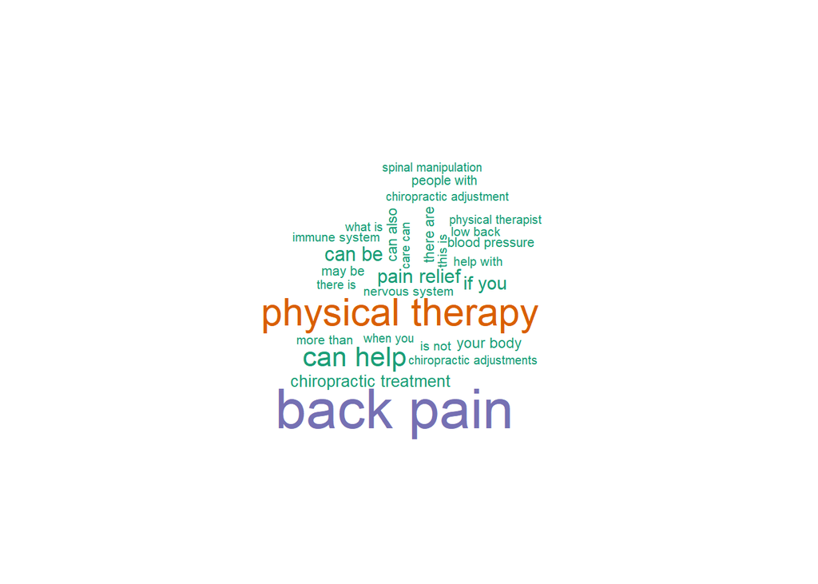

```r
wordcloud(names(freqChiropractor), freqChiropractor,
          min.freq=80,colors=brewer.pal(3,'Dark2'))
```

The above word cloud shows the top frequency bigram word pairs for chiropractic services.

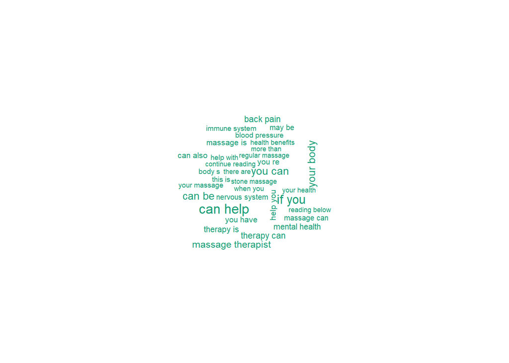

```r
wordcloud(names(freqMassage), freqMassage, min.freq=100,colors=brewer.pal(3,'Dark2'))
```

The above word cloud is for massage therapy services word pairs used most often.

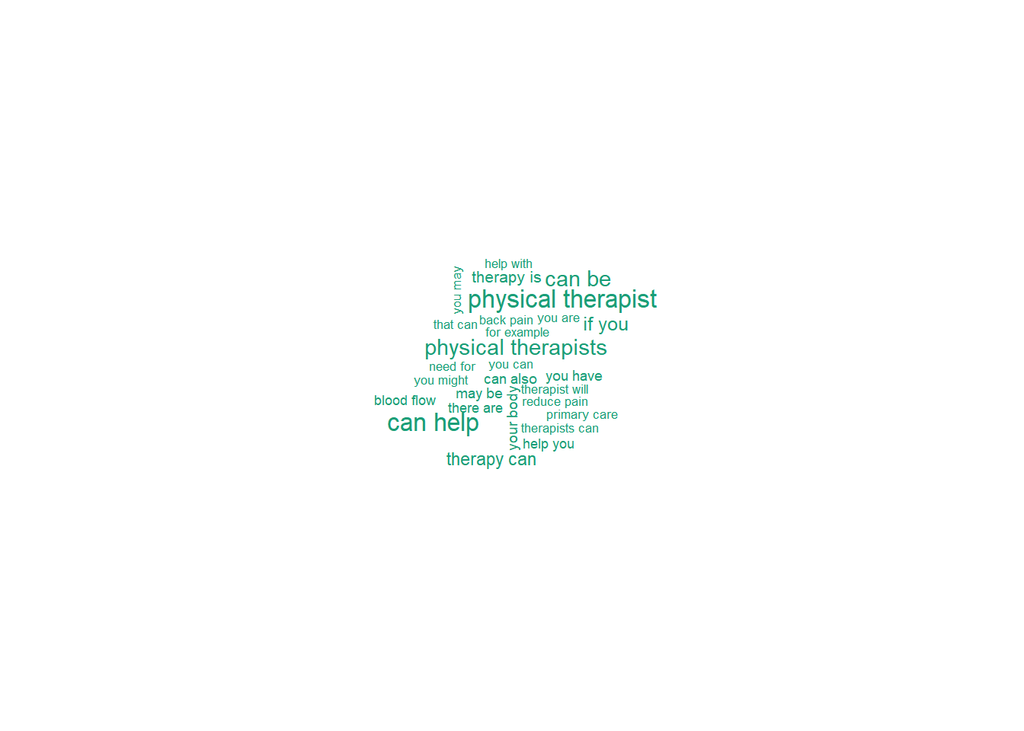

```r
wordcloud(names(freqPhysical), freqPhysical,
          min.freq=80,colors=brewer.pal(3,'Dark2'))
```

The above word cloud is the bigram word pairs used in physical therapy services documents in the data.

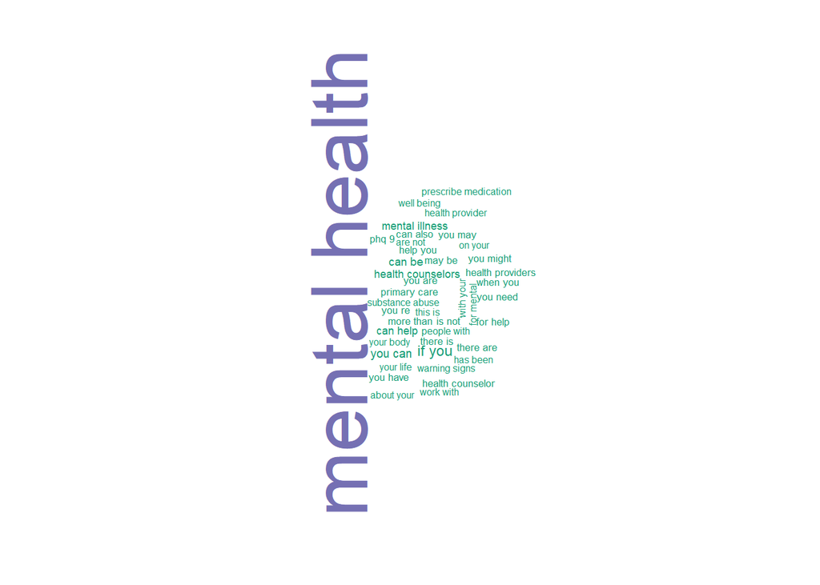

```r
wordcloud(names(freqMental), freqMental,
          min.freq=80,colors=brewer.pal(3,'Dark2'))
```

The above word cloud is for word pairs used frequently in mental health documents.

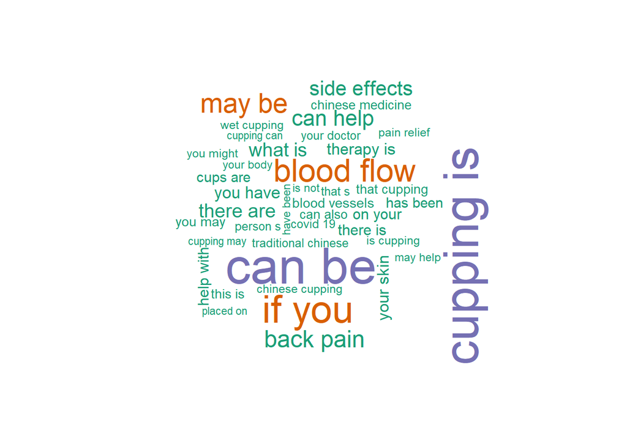

```r
wordcloud(names(freqCupping), freqCupping,
          min.freq=80,colors=brewer.pal(3,'Dark2'))
```

The above word cloud is for cupping therapy services.

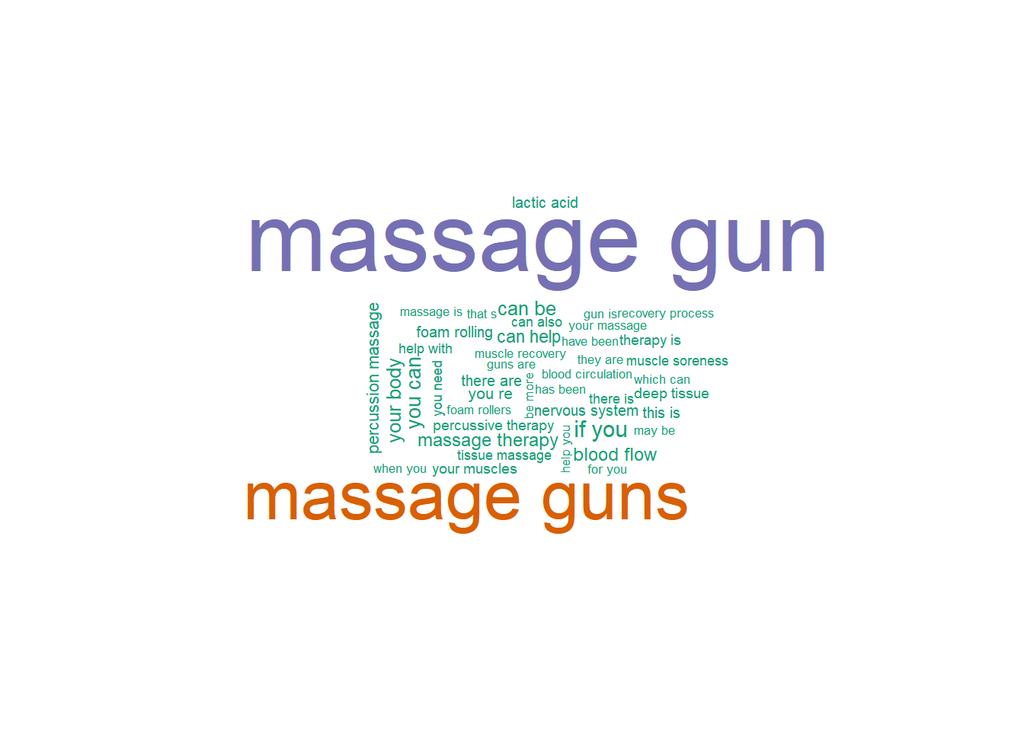

```r
wordcloud(names(freqMassageGun), freqMassageGun,
          min.freq=80,colors=brewer.pal(3,'Dark2'))
```

The above word cloud is for the massage gun services bigram word pairings in our documents on that category.

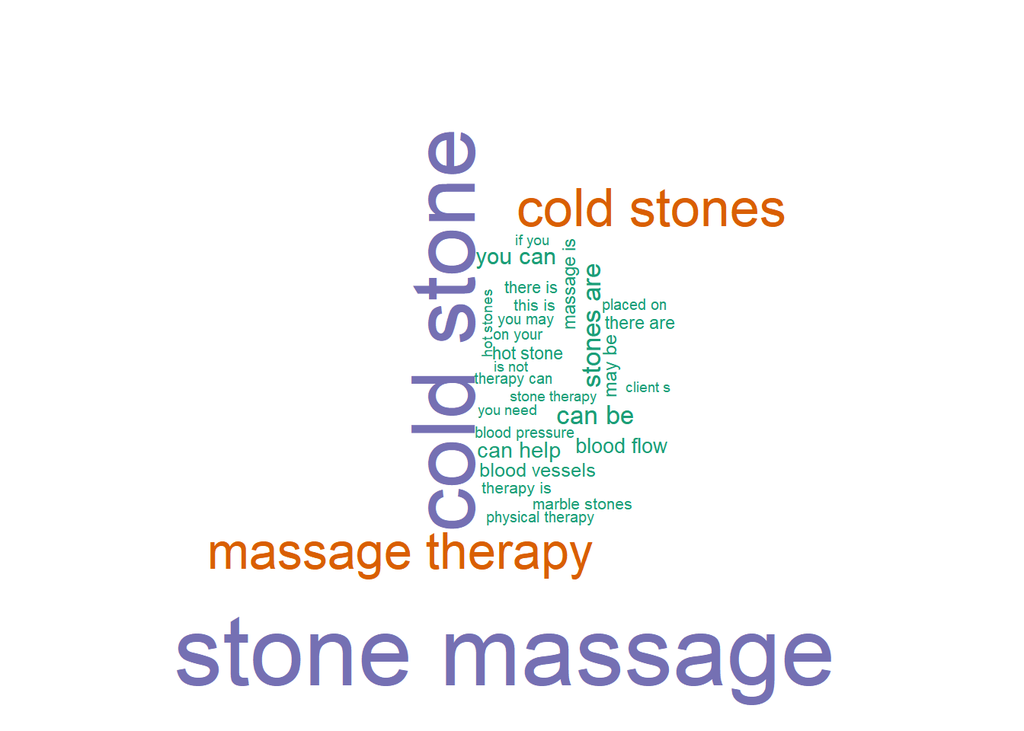

```r
wordcloud(names(freqColdStone), freqColdStone,
          min.freq=80,colors=brewer.pal(3,'Dark2'))
```

This last word cloud above is for cold stone massage therapy bigram word pairs in the documents on cold stone therapy benefits and contraindications.

Looking forward to improving this recommendation system for healthcare services, we need to test these vectorizations, TF-IDF and N-grams, on the previous dataset withou scrubbed risks and without the ER added class and see how well the results produced get towards 100% accuracy. Also, maybe adding in longer inputs for the Non Professional services, but there is a huge caveat of digging into offensive domain territory and being exposed to non-professional and vagrant smut in the process that could open this source to computer virus attacks or inappropriate recommender systems based on the cookies stored when visiting those sites. The latter could be prevented by deleting cookies and browsing private, but the exposure to offensive materials exists in scrubbing the web of longer document content to fill the Non Professional services category, so that the short user inputs won’t keep classifying them as ‘Non Professional Services’ when clearly some are options for massage gun, chiroprator, ER, or physical therapy.

Another approach would be to take those words that are useful or beneficial to each healthcare service as a recommendation, without the filler content and then make a list of those risks and contraindications for each class of healthcare services or non-professional services. Then in those lists, when the user input is short and concise, the list of options to choose from will be calculated as the option with the highest probability, and if the user separately lists in a different user input any health problems and/or symptoms as a list, then that could choose to knock out the healthcare services that those symptoms are a contraindication for. Such as, if a user says they have pain in their back, but can’t sleep because of the pain, have been feeling overheated, have a history of seizures, and maybe is nautious, then the first recommnder will recommend massage, physical therapy, or any other professional healthcare services, but once the user puts in the list of symptoms, the massage and possibly chiropractic and non-professional services would be eliminated leaving only the recommendation for ER services, chiropractic, or physical therapy healthcare services.

Another option to add to the above, is to use the single word or ngrams equal to one word clouds and eliminating stopwords.

```r
modalities <- read.csv('benefitsContraindications3.csv',
                              sep=',', header=TRUE, na.strings=c('',' ','NA'))
```

```r
colnames(modalities)
```

```
## [1] "Document"            "Source"              "Topic"
## [4] "InternetSearch"      "Contraindications"   "risksAdverseEffects"
```

```r
modalities1 <- modalities[,c(1,3)]
head(modalities1)
```

[output not shown]

We are to make our data table into a dplyr tibble.

```r
text_df <- tibble(line=1:87, text=modalities1$Document,
                  Recommend=modalities1$Topic)
head(text_df)
```

```
## # A tibble: 6 x 3
##    line text                                                   Recommend
##   <int> <fct>                                                  <fct>
## 1     1 "Chiropractic adjustments and treatments serve the ne~ chiropractic ben~
## 2     2 "\nUnitedHealthcare Combats Opioid Crisis with Non-Op~ chiropractic ben~
## 3     3 " The Safety of Chiropractic Adjustments\nBy Lana Bar~ chiropractic ben~
## 4     4 "Advanced Chiropractic Relief: 8 Key Benefits of Chir~ chiropractic ben~
## 5     5 "Heading to the spa can be a pampering treat, but it ~ massage benefits
## 6     6 "Massage: Get in touch with its many benefits\n\nMass~ massage benefits
```

```r
text_df$text <- as.character(paste(text_df$text))

library(stopwords)
stop <- as.data.frame(stopwords())
colnames(stop) <- 'fillers'
# fills <- as.data.frame(c('of','the','a','an','in','by','it','as','or','go','goes','am','and','to'))
# colnames(fills) <- 'fillers'

text_df0 <- text_df %>% unnest_tokens(unigram,text,token='ngrams',n=1)

text_df01 <- anti_join(text_df0,stop, by=c("unigram"="fillers"))
```

```r
text_df4 <- text_df01 %>% group_by(unigram) %>% count(unigram, sort=TRUE)
head(text_df4,30)
```

```
## # A tibble: 30 x 2
## # Groups:   unigram [30]
##    unigram      n
##    <chr>    <int>
##  1 massage    667
##  2 can        479
##  3 pain       347
##  4 therapy    328
##  5 health     298
##  6 help       263
##  7 cupping    261
##  8 physical   236
##  9 body       221
## 10 may        196
## # ... with 20 more rows
```

```r
er <- subset(text_df01, text_df01$Recommend=='ER')
nonPro <- subset(text_df01, text_df01$Recommend=='Not Professional')
chiropractor <- subset(text_df01, text_df01$Recommend=='chiropractic benefits')
massage <- subset(text_df01, text_df01$Recommend=='massage benefits')
physicalTherapy <- subset(text_df01, text_df01$Recommend=='physical therapy benefits')
mental <- subset(text_df01, text_df01$Recommend=='mental health services benefits')
cupping <- subset(text_df01, text_df01$Recommend=='cupping benefits')
massageGun <- subset(text_df01, text_df01$Recommend=='massage gun benefits')
coldStone <- subset(text_df01, text_df01$Recommend=='cold stone benefits')
```

```r
er2 <- er %>% group_by(unigram) %>% count(unigram, sort=TRUE)
er3 <- spread(er2,unigram,n)
freqER <- colSums(er3)

nonPro2 <- nonPro %>% group_by(unigram) %>% count(unigram, sort=TRUE)
nonPro3 <- spread(nonPro2,unigram,n)
freqNonPro <- colSums(nonPro3)

chiropractor2 <- chiropractor %>% group_by(unigram) %>% count(unigram, sort=TRUE)
chiropractor3 <- spread(chiropractor2,unigram,n)
freqChiropractor <- colSums(chiropractor3)

massage2 <- massage %>% group_by(unigram) %>% count(unigram, sort=TRUE)
massage3 <- spread(massage2,unigram,n)
freqMassage <- colSums(massage3)

physical2 <- physicalTherapy %>% group_by(unigram) %>% count(unigram, sort=TRUE)
physical3 <- spread(physical2,unigram,n)
freqPhysical <- colSums(physical3)

mental2 <- mental %>% group_by(unigram) %>% count(unigram, sort=TRUE)
mental3 <- spread(mental2,unigram,n)
freqMental <- colSums(mental3)

cupping2 <- cupping %>% group_by(unigram) %>% count(unigram, sort=TRUE)
cupping3 <- spread(cupping2,unigram,n)
freqCupping <- colSums(cupping3)

massageGun2 <- massageGun %>% group_by(unigram) %>% count(unigram, sort=TRUE)
massageGun3 <- spread(massageGun2,unigram,n)
freqMassageGun <- colSums(massageGun3)

coldStone2 <- coldStone %>% group_by(unigram) %>% count(unigram, sort=TRUE)
coldStone3 <- spread(coldStone2,unigram,n)
freqColdStone <- colSums(coldStone3)
```

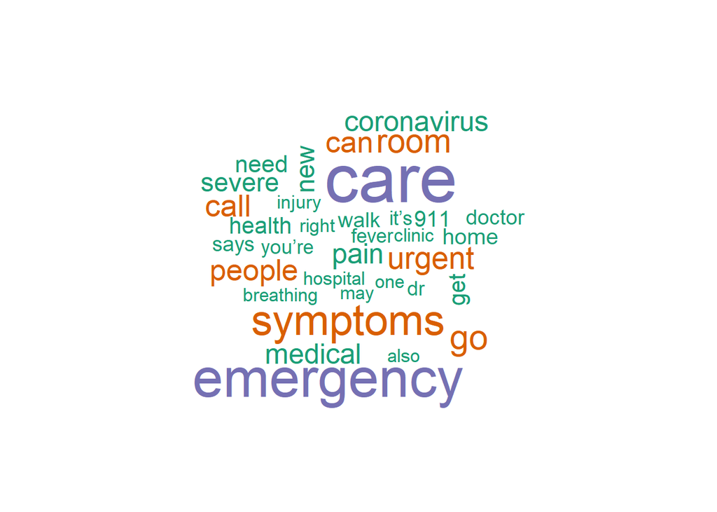

```r
wordcloud(names(freqER), freqER,
          min.freq=10,colors=brewer.pal(3,'Dark2'))
```

The above word cloud is for Emergency Room services from qualified medical staff such as doctors and nurses.

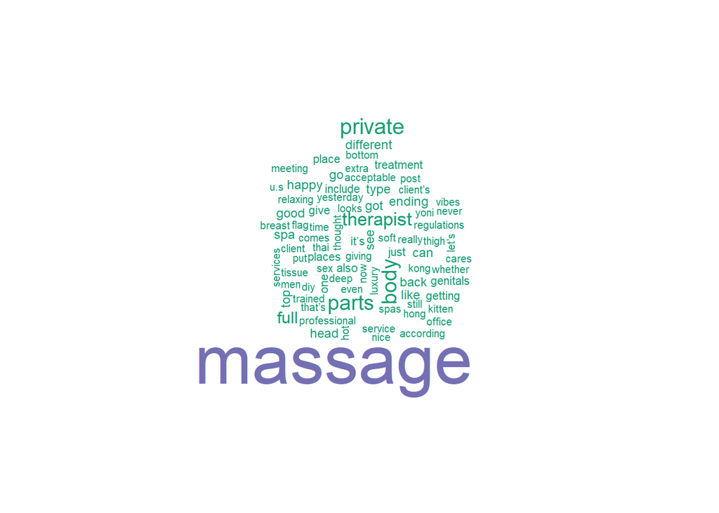

```r
wordcloud(names(freqNonPro), freqNonPro,
          min.freq=2,colors=brewer.pal(3,'Dark2'))
```

The word cloud above is for non-professional services. It was scrubbed from twitter using massage, but these tweets were not for professional massage services or requests.

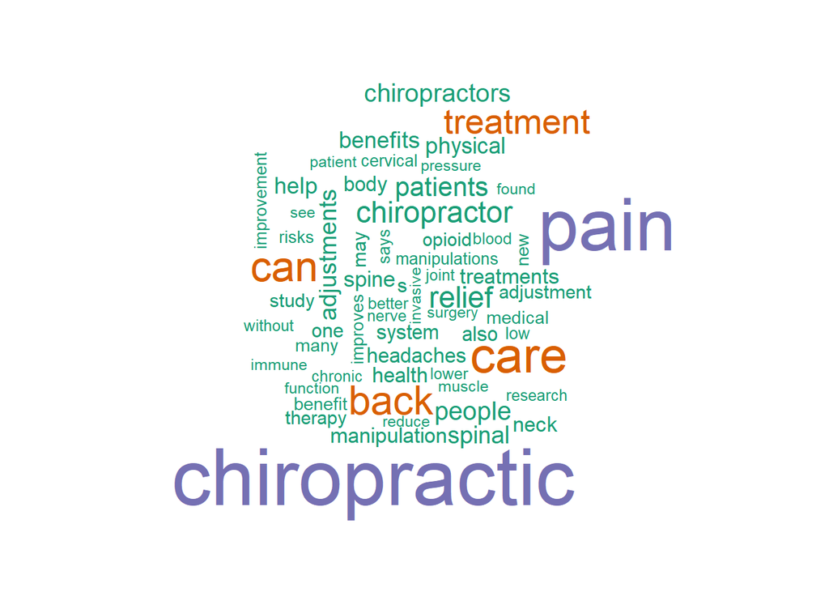

```r
wordcloud(names(freqChiropractor), freqChiropractor,
          min.freq=9,colors=brewer.pal(3,'Dark2'))
```

The word cloud above is for chiropractic services.

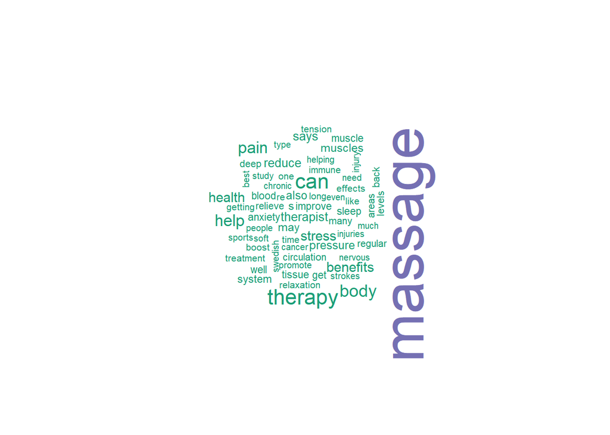

```r
wordcloud(names(freqMassage), freqMassage, min.freq=9,colors=brewer.pal(3,'Dark2'))
```

The word cloud above is for massage therapy.

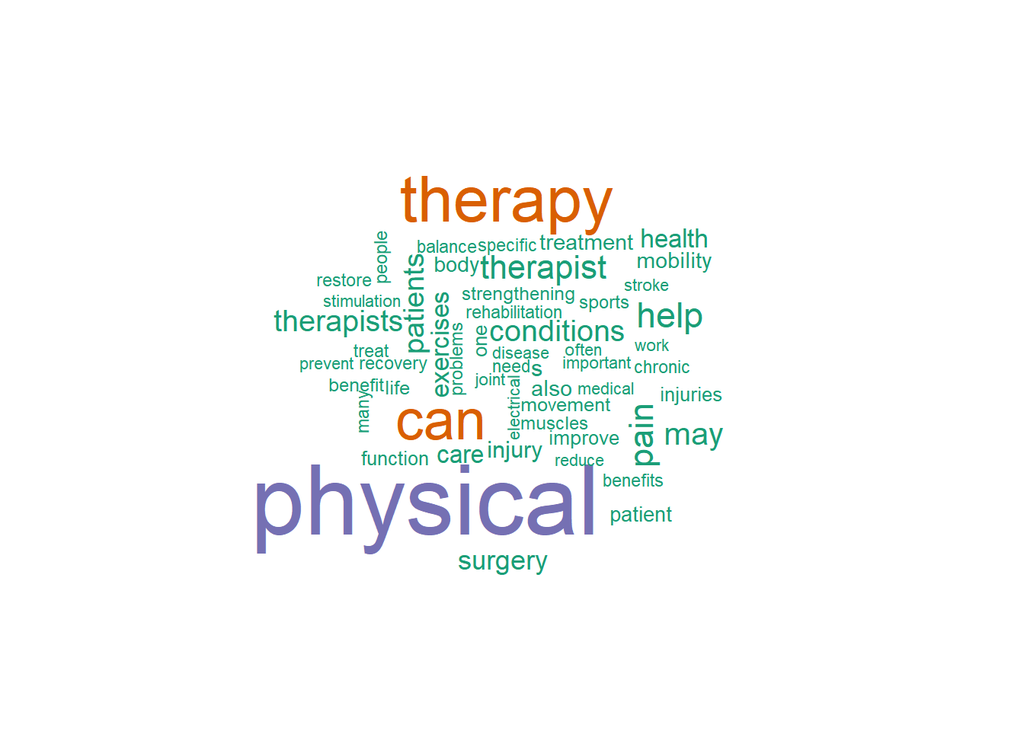

```r
wordcloud(names(freqPhysical), freqPhysical,
          min.freq=10,colors=brewer.pal(3,'Dark2'))
```

The word cloud above is for physical therapy.

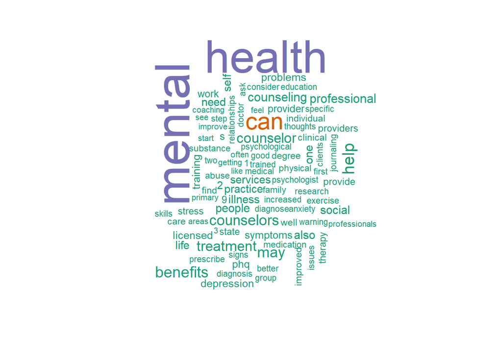

```r
wordcloud(names(freqMental), freqMental,
          min.freq=10,colors=brewer.pal(3,'Dark2'))
```

The word cloud above is for mental health services.

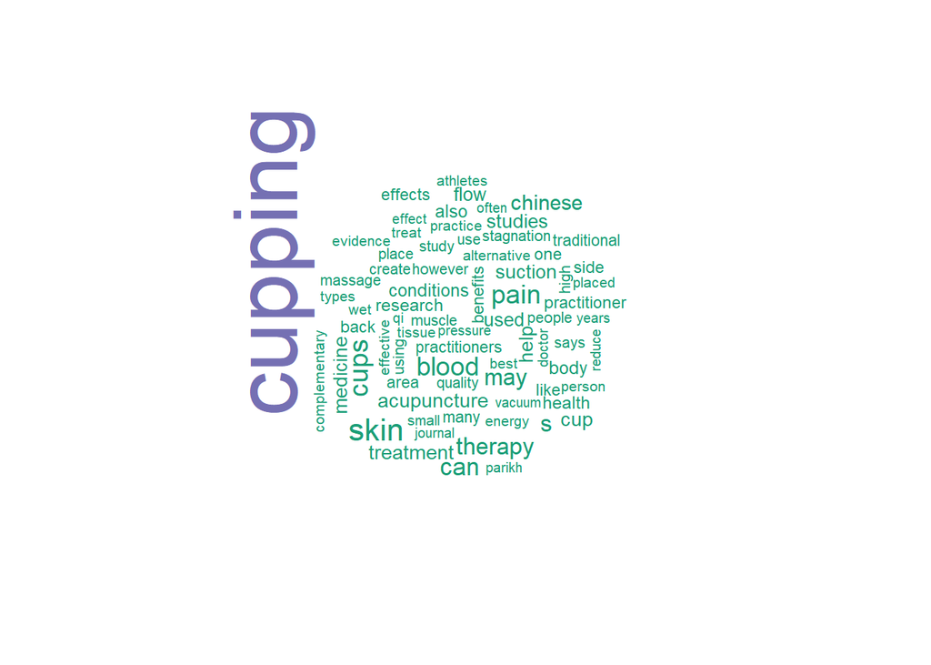

```r
wordcloud(names(freqCupping), freqCupping,
          min.freq=10,colors=brewer.pal(3,'Dark2'))
```

The word cloud above is for cupping therapy.

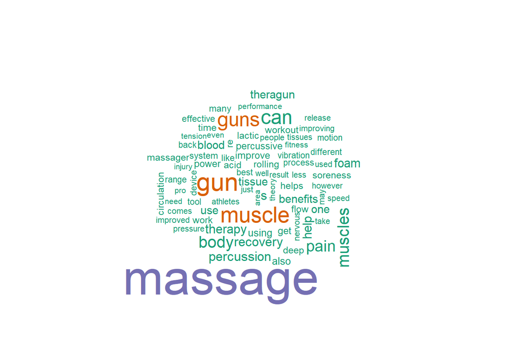

```r
wordcloud(names(freqMassageGun), freqMassageGun,
          min.freq=10,colors=brewer.pal(3,'Dark2'))
```

The wordcloud above is for massage gun therapy.

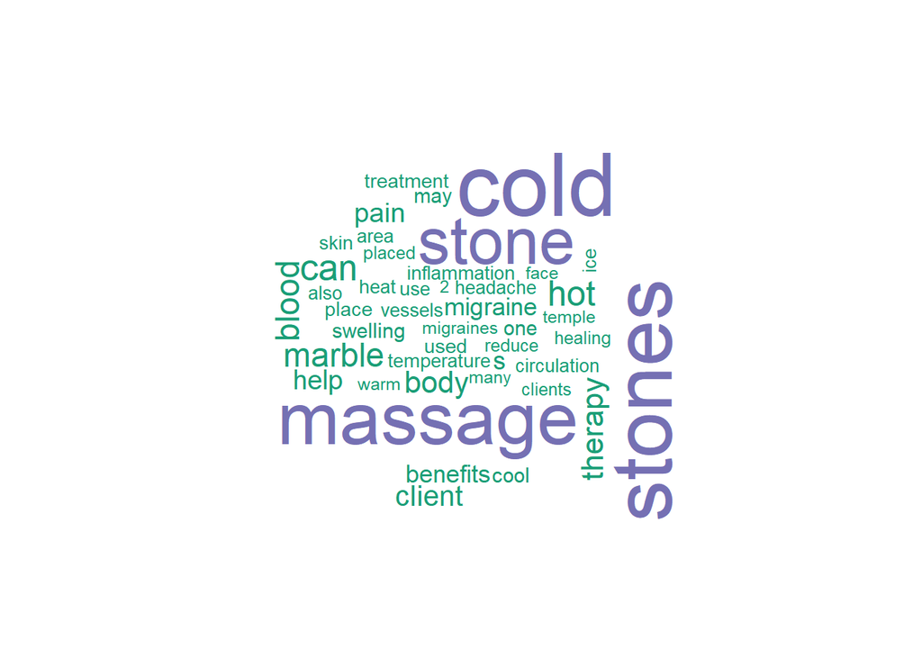

```r
wordcloud(names(freqColdStone), freqColdStone,
          min.freq=10,colors=brewer.pal(3,'Dark2'))
```

This word cloud above is for Cold stone therapy.

We saw how the count, tf-idf, and n-grams vectorized tokens for a dtm work. And found that the range of accuracy with our new added category for ER services, and the scrubbed risks and contraindications out of our health services’ documents, did score better than the last script with the added ‘Not Professional Services’ category and keeping the risks and contraindications within each document. Because that other previous model scored 62% on the testing set using only the count vectorization. And this script’s models ranged from 72-83% accuracy on the testing sets, with some questionable recommendations on the short user inputs. Both of the count and n-grams set to bigrams or 2 word adjacent pairings scored 72% on the testing sets, and the tf-idf scored 83% on the testing set. We saw in the first and second script that excluded the added ‘Not Professional Services’ category and included the risks and contraindications scored 92% and had better recommendations in the short user inputs as well.

Any of these models would be ok to use for fun, but they would still need to be improved by supplying better data in the first place, or by testing out other algorithms that could be time consuming such as the trees that random forest and rpart or gradient boosting trees.